```r
library(tidyverse)
library(here)
library(dplyr)
library(janitor)
library(tidyverse)
```

```r
c1 = read.csv("cancerstats1.csv")
```

```r
top20states <- top_n(c1, 20, Percentage.of.cases)
top20states
```

```
##              Area           Cancer.Type Case.Count Population
## 1   Massachusetts Melanomas of the Skin       1297    6894883
## 2        New York Melanomas of the Skin       4444   19463131
## 3     Connecticut Melanomas of the Skin        900    3566022
## 4     Mississippi Melanomas of the Skin        667    2978227
## 5         Alabama Melanomas of the Skin       1182    4907965
## 6    North Dakota Melanomas of the Skin        177     763724
## 7        Colorado Melanomas of the Skin       1351    5758486
## 8      New Jersey Melanomas of the Skin       2392    8891258
## 9    Rhode Island Melanomas of the Skin        292    1058158
## 10       Virginia Melanomas of the Skin       2226    8556642
## 11      Wisconsin Melanomas of the Skin       1640    5824581
## 12        Florida Melanomas of the Skin       7503   21492056
## 13        Georgia Melanomas of the Skin       2964   10628020
## 14       Maryland Melanomas of the Skin       1933    6054954
```

[output cut: 48 more lines]

```r
c2 = read_csv("cancerstats3.csv")
c2
```

```
## # A tibble: 5 × 6
##   Race                       `Cancer Type` Sex   `Case Count` Population Percent
##   <chr>                      <chr>         <chr>        <dbl>      <dbl>   <dbl>
## 1 Hispanic                   Melanomas of… Male…         1126   29481430    0.6
## 2 Asian and Pacific Islande… Melanomas of… Male…          132   10775928    0.04
## 3 American Indian and Alask… Melanomas of… Male…          110    1388337    0.07
## 4 Black Non-Hispanic         Melanomas of… Male…          205   22401024    0.1
## 5 White Non-Hispanic         Melanomas of… Male…        47720   98260319    2.6
```

```r
c3 = read.csv("cancerstats2.csv")
c3
```

```
##             Area           Cancer.Type Year Age.Adjusted.Rate Case.Count
## 1  United States Melanomas of the Skin 1999              15.1      41148
## 2  United States Melanomas of the Skin 2000              16.1      44499
## 3  United States Melanomas of the Skin 2001              17.1      48011
## 4  United States Melanomas of the Skin 2002              17.4      49843
## 5  United States Melanomas of the Skin 2003              17.2      50385
## 6  United States Melanomas of the Skin 2004              18.2      54188
## 7  United States Melanomas of the Skin 2005              19.5      58836
## 8  United States Melanomas of the Skin 2006              19.3      59200
## 9  United States Melanomas of the Skin 2007              19.7      61709
## 10 United States Melanomas of the Skin 2008              20.0      63806
## 11 United States Melanomas of the Skin 2009              20.4      66167
## 12 United States Melanomas of the Skin 2010              20.1      66387
## 13 United States Melanomas of the Skin 2011              20.7      69573
## 14 United States Melanomas of the Skin 2012              20.7      71114
```

[output cut: 29 more lines]

Motivation for my analysis: Growing up, I used to always lay out in the sun and get burnt, and my sister who is a dermatologist would always tell me how dangerous the sun is. I learned more about it, was shocked by what I found, and completely stopped tanning and became much more careful about protecting myself. Luckily, I was able to stop at an early age, but many people are unaware of how dangerous the sun really is. I want to spread awareness so they can begin to protect themselves too.

Introduction: Skin cancer is the most common form of cancer. One in five people will develop it and ten thousand people are diagnosed with it every day. More than two people die of skin cancer in the U.S. every hour. According to the FDA, the annual cost of treating skin cancers in the U.S. is slightly over 8 billion dollars. More people are diagnosed with skin cancer each year in the U.S. than all other cancers combined. The most common way people can get skin cancer is from the UV radiation emitted by the sun. The Skin Cancer Foundation even says that sunscreen alone can’t protect from the dangers of the sun.

Data Collection: I collected data from the Centers of Disease Control and Prevention (CDC) as part of the “Cancer Data”. I collected three different data sets. - The first data set is trends and rates of skin cancer for every state in the US. I narrowed it down to 20 different states that I was interested in. - The second data set is skin cancer rates for the different races in the US for males and females. - The third data set is how the number of skin cancer cases in the US have changed over time.

Before the analysis, let’s clean up the data and transform it

```r
clean = clean_names(top20states)
colnames(clean)
```

```
## [1] "area"                 "cancer_type"          "case_count"
## [4] "population"           "percentage_of_cases"  "white_percentage"
## [7] "annual_sunshine_days" "percentage_above_65"  "percent_sun"
```

```r
clean2 = clean_names(c2)
colnames(clean2)
```

```
## [1] "race"        "cancer_type" "sex"         "case_count"  "population"
## [6] "percent"
```

```r
clean3 = clean_names(c3)
colnames(clean3)
```

```
## [1] "area"              "cancer_type"       "year"
## [4] "age_adjusted_rate" "case_count"        "population"
```

```r
clean_x = clean %>% remove_empty(whic=c("rows"))
clean_x = clean %>% remove_empty(whic=c("cols"))
clean_x2 = clean2 %>% remove_empty(whic=c("rows"))
clean_x2 = clean2 %>% remove_empty(whic=c("cols"))
clean_x3 = clean3 %>% remove_empty(whic=c("rows"))
clean_x3 = clean3 %>% remove_empty(whic=c("cols"))
clean_x
```

```
##              area           cancer_type case_count population
## 1   Massachusetts Melanomas of the Skin       1297    6894883
## 2        New York Melanomas of the Skin       4444   19463131
## 3     Connecticut Melanomas of the Skin        900    3566022
## 4     Mississippi Melanomas of the Skin        667    2978227
## 5         Alabama Melanomas of the Skin       1182    4907965
## 6    North Dakota Melanomas of the Skin        177     763724
## 7        Colorado Melanomas of the Skin       1351    5758486
## 8      New Jersey Melanomas of the Skin       2392    8891258
## 9    Rhode Island Melanomas of the Skin        292    1058158
## 10       Virginia Melanomas of the Skin       2226    8556642
## 11      Wisconsin Melanomas of the Skin       1640    5824581
## 12        Florida Melanomas of the Skin       7503   21492056
## 13        Georgia Melanomas of the Skin       2964   10628020
## 14       Maryland Melanomas of the Skin       1933    6054954
```

[output cut: 48 more lines]

```r
clean_x2
```

```
## # A tibble: 5 × 6
##   race                           cancer_type sex   case_count population percent
##   <chr>                          <chr>       <chr>      <dbl>      <dbl>   <dbl>
## 1 Hispanic                       Melanomas … Male…       1126   29481430    0.6
## 2 Asian and Pacific Islander No… Melanomas … Male…        132   10775928    0.04
## 3 American Indian and Alaska Na… Melanomas … Male…        110    1388337    0.07
## 4 Black Non-Hispanic             Melanomas … Male…        205   22401024    0.1
## 5 White Non-Hispanic             Melanomas … Male…      47720   98260319    2.6
```

```r
clean_x3
```

```
##             area           cancer_type year age_adjusted_rate case_count
## 1  United States Melanomas of the Skin 1999              15.1      41148
## 2  United States Melanomas of the Skin 2000              16.1      44499
## 3  United States Melanomas of the Skin 2001              17.1      48011
## 4  United States Melanomas of the Skin 2002              17.4      49843
## 5  United States Melanomas of the Skin 2003              17.2      50385
## 6  United States Melanomas of the Skin 2004              18.2      54188
## 7  United States Melanomas of the Skin 2005              19.5      58836
## 8  United States Melanomas of the Skin 2006              19.3      59200
## 9  United States Melanomas of the Skin 2007              19.7      61709
## 10 United States Melanomas of the Skin 2008              20.0      63806
## 11 United States Melanomas of the Skin 2009              20.4      66167
## 12 United States Melanomas of the Skin 2010              20.1      66387
## 13 United States Melanomas of the Skin 2011              20.7      69573
## 14 United States Melanomas of the Skin 2012              20.7      71114
```

[output cut: 29 more lines]

```r
c2 %>% pivot_longer(c(`Case Count`, `Population`, `Percent`),
                           names_to="Stats",
                           values_to="Values")
```

```
## # A tibble: 15 × 5
##    Race                                        `Cancer Type` Sex   Stats  Values
##    <chr>                                       <chr>         <chr> <chr>   <dbl>
##  1 Hispanic                                    Melanomas of… Male… Case… 1.13e+3
##  2 Hispanic                                    Melanomas of… Male… Popu… 2.95e+7
##  3 Hispanic                                    Melanomas of… Male… Perc… 6   e-1
##  4 Asian and Pacific Islander Non-Hispanic     Melanomas of… Male… Case… 1.32e+2
##  5 Asian and Pacific Islander Non-Hispanic     Melanomas of… Male… Popu… 1.08e+7
##  6 Asian and Pacific Islander Non-Hispanic     Melanomas of… Male… Perc… 4   e-2
##  7 American Indian and Alaska Native Non-Hisp… Melanomas of… Male… Case… 1.1 e+2
##  8 American Indian and Alaska Native Non-Hisp… Melanomas of… Male… Popu… 1.39e+6
##  9 American Indian and Alaska Native Non-Hisp… Melanomas of… Male… Perc… 7   e-2
## 10 Black Non-Hispanic                          Melanomas of… Male… Case… 2.05e+2
## 11 Black Non-Hispanic                          Melanomas of… Male… Popu… 2.24e+7
## 12 Black Non-Hispanic                          Melanomas of… Male… Perc… 1   e-1
## 13 White Non-Hispanic                          Melanomas of… Male… Case… 4.77e+4
## 14 White Non-Hispanic                          Melanomas of… Male… Popu… 9.83e+7
## 15 White Non-Hispanic                          Melanomas of… Male… Perc… 2.6 e+0
```

Now, let’s do some analysis on each data set

```r
library(ggplot2)
```

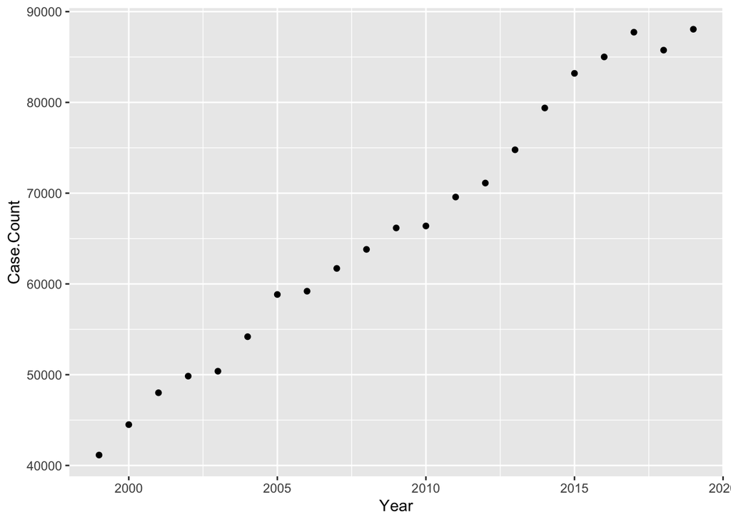

```r
ggplot(data = c3, aes(x = `Year`, y = `Case.Count`)) + geom_point()
```

```r
mean(c3$Case.Count)
```

```
## [1] 66132.52
```

```r
mean(c3$Population)
```

```
## [1] 304620123
```

There is an average of about 66,132 cases per year out of an average of a 304,620,123 population

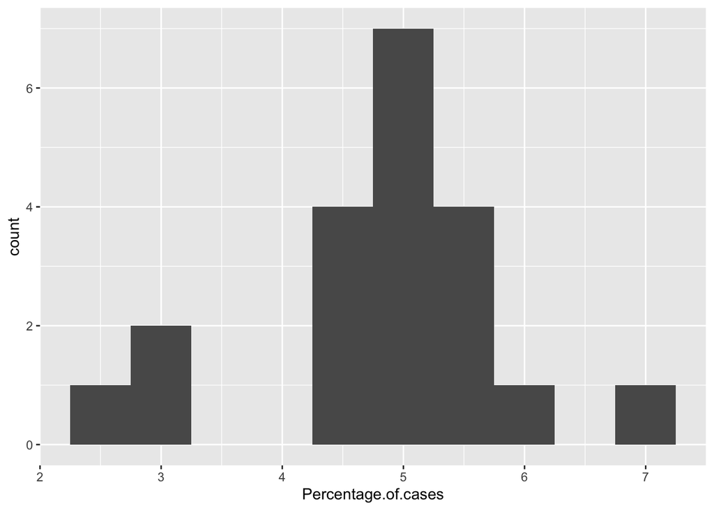

```r
ggplot(data = top20states, aes(x= `Percentage.of.cases`)) + geom_histogram(binwidth = .5)
```

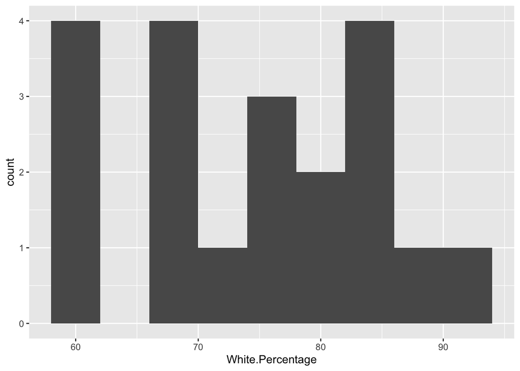

```r
top20states$Case.Count<- as.numeric(as.character(top20states$Case.Count))
ggplot(data = top20states, aes(x= `White.Percentage`)) + geom_histogram(binwidth = 4)
```

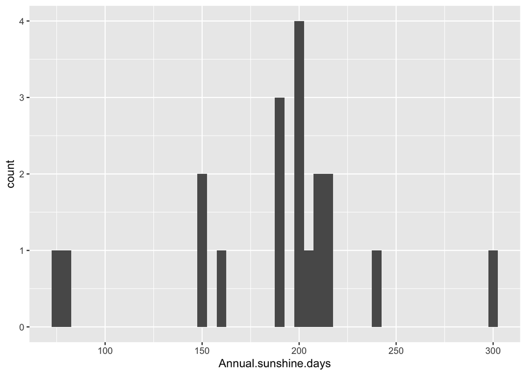

```r
ggplot(data = top20states, aes(x= `Annual.sunshine.days`)) + geom_histogram(binwidth = 5)
```

Looking at data set 2 (c2) and seeing that white people are more prone to skin cancer, let’s see whether there is a correlation between the states with a greater percentage of white people and the percentage of skin cancer cases in that state.

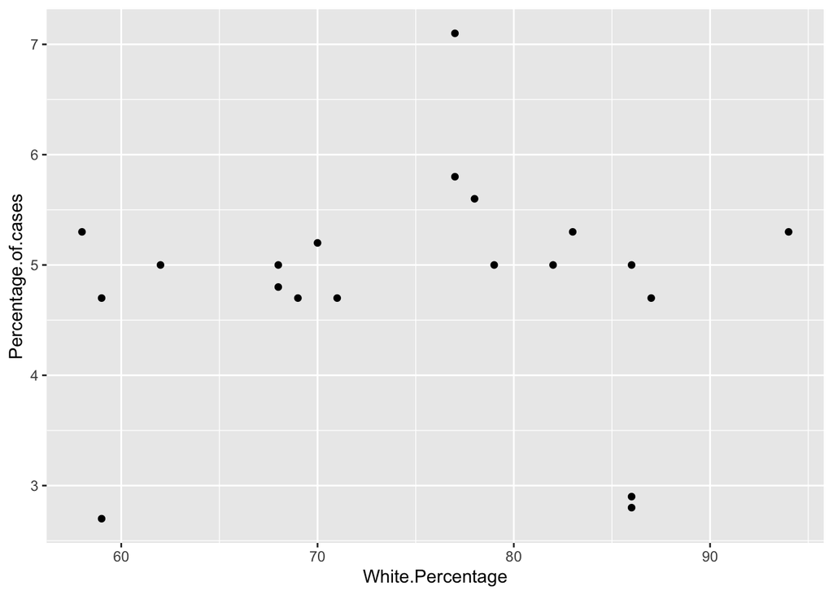

```r
ggplot(data = top20states, aes(x = `White.Percentage`, y = `Percentage.of.cases`)) + geom_point()
```

Surprisingly, there doesn’t seem to be a major correlation as I expected. There is no pattern in this plot.

Now, let’s see whether there is a correlation between the states with more annual sunshine days and their number of skin cancer cases.

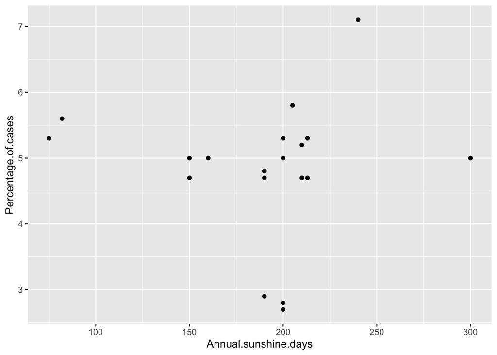

```r
ggplot(data = top20states, aes(x = `Annual.sunshine.days`, y = `Percentage.of.cases`)) + geom_point()
```

There doesn’t seem to be a major pattern.

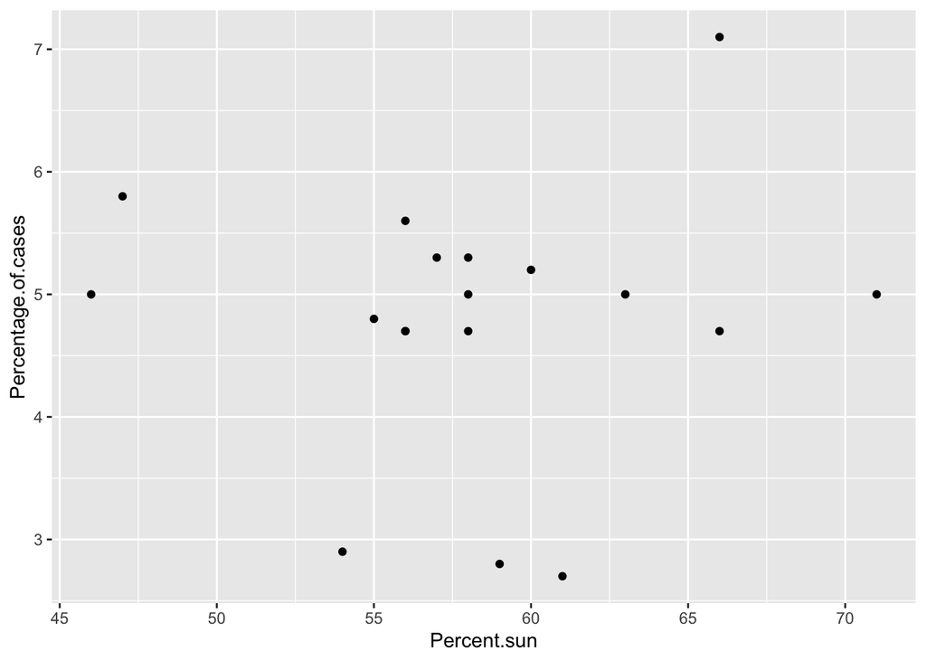

```r
top20states$Case.Count <- as.numeric(as.character(top20states$Case.Count))
ggplot(data = top20states, aes(x = `Percent.sun`, y = `Percentage.of.cases`)) + geom_point()
```

There doesn’t seem to be a major correlation.

```r
msun <- lm(Percentage.of.cases ~ `Annual.sunshine.days` , data = top20states)
summary(msun)
```

```
##
## Call:
## lm(formula = Percentage.of.cases ~ Annual.sunshine.days, data = top20states)
##
## Residuals:
##     Min      1Q  Median      3Q     Max
## -2.1160 -0.1160  0.1666  0.4568  2.3014
##
## Coefficients:
##                        Estimate Std. Error t value Pr(>|t|)
## (Intercept)           4.9030045  0.9851986   4.977 0.000115 ***
## Annual.sunshine.days -0.0004352  0.0050616  -0.086 0.932489
## ---
## Signif. codes:  0 '***' 0.001 '**' 0.01 '*' 0.05 '.' 0.1 ' ' 1
##
## Residual standard error: 1.086 on 17 degrees of freedom
##   (1 observation deleted due to missingness)
## Multiple R-squared:  0.0004346,  Adjusted R-squared:  -0.05836
## F-statistic: 0.007392 on 1 and 17 DF,  p-value: 0.9325
```

```r
mw <- lm(Percentage.of.cases ~ `White.Percentage` , data = top20states)
summary(mw)
```

```
##
## Call:
## lm(formula = Percentage.of.cases ~ White.Percentage, data = top20states)
##
## Residuals:
##     Min      1Q  Median      3Q     Max
## -2.0965 -0.1186  0.1583  0.4358  2.2657
##
## Coefficients:
##                  Estimate Std. Error t value Pr(>|t|)
## (Intercept)      4.672737   1.719681   2.717   0.0141 *
## White.Percentage 0.002098   0.022727   0.092   0.9275
## ---
## Signif. codes:  0 '***' 0.001 '**' 0.01 '*' 0.05 '.' 0.1 ' ' 1
##
## Residual standard error: 1.056 on 18 degrees of freedom
## Multiple R-squared:  0.0004733,  Adjusted R-squared:  -0.05506
## F-statistic: 0.008524 on 1 and 18 DF,  p-value: 0.9275
```

```r
mps <- lm(Percentage.of.cases ~ `Percent.sun` , data = top20states)
summary(mps)
```

```
##
## Call:
## lm(formula = Percentage.of.cases ~ Percent.sun, data = top20states)
##
## Residuals:
##      Min       1Q   Median       3Q      Max
## -2.12203 -0.08795  0.11955  0.47731  2.22929
##
## Coefficients:
##             Estimate Std. Error t value Pr(>|t|)
## (Intercept) 4.228113   2.570811   1.645    0.120
## Percent.sun 0.009736   0.043967   0.221    0.828
##
## Residual standard error: 1.111 on 16 degrees of freedom
##   (2 observations deleted due to missingness)
## Multiple R-squared:  0.003055,   Adjusted R-squared:  -0.05925
## F-statistic: 0.04904 on 1 and 16 DF,  p-value: 0.8275
```

After researching more about sunscreen, it is clear that anyone who isn’t careful about a sun protection strategy is at a high risk, wherever they live. According to all, sunscreen itself is not enough and one must have other forms of protection too. For example, sitting in the shade, wearing a sunhat, and wearing sunglasses are all parts of a proper sun protection strategy.